# Estimation départementale de la prévalence du tabagisme quotidien en France métropolitaine

Abdelkrim Zeghnoun

29 decembre 2023

L’objectif est d’explorer l’utilisation des méthodes d’estimation sur petits domaines pour produire des estimations à l’échelon départemental de la prévalence du tabagisme quotidien. Les méthodes directe et de Fay et Herriot (FH) sont comparées.

Nous commençons par charger les librairies et données nécessaires.

```r
# Chargement des librairies
library(emdi)       # SAE package
library(survey)     # Survey estimation

library(maptools)   # Pour la carte départementale
library(spdep)
library(sp)

rm(list=ls())

# Chargement des données
load(url("https://github.com/zakyaz/SAE/raw/main/projetbaro21SAEdemo.Rdata"))
```

Avant de construire le modèle de FH, nous vérifions la présence d’autocorrélation spatiale dans les données de tabagisme quotidien (corrélation entre les données géographiquement voisines). Pour cela nous utilisons les indices C de Geary et I de Morane qui sont des mesures de l’autocorrelation spatiale. Si l’autocorrélation spatiale est significative, elle est inclue dans le modèle de FH.

La valeur de l’indice de Geary varie entre 0 et 2 : 1 signifie qu’aucune autocorrelation spatiale n’est presente. Une valeur plus petite (resp. plus grande) que 1 indique une autocorrelation spatiale positive (resp. negative).

Concernant l’indice de Moran, les valeurs négatives (resp. positives) indiquent une autocorrélation spatiale négative (resp. positive). Ses valeurs s’étendent de -1 (dispersion parfaite) a 1 (corrélation parfaite). Une valeur nulle indique un modèle spatial parfaitement aléatoire.

Les indices de Moran et de Geary indiquent une faible autocorrélation spatiale dans les données du tabagisme quotidien.

```r
# Construction de la matrice de proximité
data_spatial=merge(depOM,fhbaro21data,by.x="INSEE_DEP",by.y="DEPARTEMENT", all.x = F)
w <- poly2nb(data_spatial, row.names=data_spatial$INSEE_DEP)
wm <-nb2mat(w,   style='W',   zero.policy=TRUE)

# Test d'autocorrélation spatiale
spatialcor.tests(direct = data_spatial$tab_quo,corMatrix = wm)
```

```
##   Statistics       Value   p.value
## 1  Moran's I -0.05437547 0.7492894
## 2  Geary's C  1.00107756 0.5063392
```

Le package **emdi** est utilisé pour construire le modèle de FH. La procédure de sélection du modèle est présentée ci-dessous. Tout d’abord, un modèle complet est construit. Nous utilisons ensuite la fonction **step** du package **emdi** pour sélectionner avec le critère d’**AIC**, les variables les plus significativement liées au tabagisme. Les variables rejetées par la fonction **step** sont ensuite testées une à une dans le modèle retenu par cette fonction. Aucune variable rejetée n’etait statistiquement significative au seuil de 15%.

Voici les résultats du modèle complet :

```r
# Modèle FH complet
fh_std <- fh(fixed = tab_quo ~  p_SEXE2_1875 + p_AGE1824 + p_AGE2534 + p_AGE3544 + p_AGE4554 + p_AGE5564 +
               diplome1+diplome2+diplome3+diplome4+
               CSP1+CSP2+CSP3+CSP4+CSP5+CSP6+CSP7+
               type_menage1+type_menage2+type_menage3+type_menage4+
               revenu_median+
               taux_activite1+taux_activite2+taux_activite3,
          vardir = "var", combined_data = fhbaro21data,
          domains = "DEPARTEMENT", MSE=TRUE,method="ml")

summary(fh_std)
```

```
## Call:
##  fh(fixed = tab_quo ~ p_SEXE2_1875 + p_AGE1824 + p_AGE2534 + p_AGE3544 +
##     p_AGE4554 + p_AGE5564 + diplome1 + diplome2 + diplome3 +
##     diplome4 + CSP1 + CSP2 + CSP3 + CSP4 + CSP5 + CSP6 + CSP7 +
##     type_menage1 + type_menage2 + type_menage3 + type_menage4 +
##     revenu_median + taux_activite1 + taux_activite2 + taux_activite3,
##     vardir = "var", combined_data = fhbaro21data, domains = "DEPARTEMENT",
##     method = "ml", MSE = TRUE)
##
## Out-of-sample domains:  0
## In-sample domains:  95
##
## Variance and MSE estimation:
## Variance estimation method:  ml
## Estimated variance component(s):  5.182771e-05
## MSE method:  datta-lahiri
##
## Coefficients:
##                coefficients  std.error t.value p.value
## (Intercept)       0.1523789  3.3103757  0.0460 0.96329
## p_SEXE2_1875      1.9906405  1.6059280  1.2396 0.21514
## p_AGE1824         5.1106893  2.1532413  2.3735 0.01762 *
## p_AGE2534         4.7802445  2.6676719  1.7919 0.07315 .
## p_AGE3544         5.5091472  2.4858303  2.2162 0.02668 *
## p_AGE4554         4.8202795  2.6022877  1.8523 0.06398 .
## p_AGE5564         6.6140052  2.5872057  2.5564 0.01058 *
## diplome1          0.3641690  0.7776099  0.4683 0.63956
## diplome2          1.5654227  1.4626961  1.0702 0.28452
## diplome3          0.2920200  0.8991430  0.3248 0.74535
## diplome4          0.1951599  1.6016833  0.1218 0.90302
## CSP1              0.7385528  2.6149264  0.2824 0.77761
## CSP2              4.5017326  3.2102869  1.4023 0.16083
## CSP3              1.8637164  2.5237509  0.7385 0.46023
## CSP4              1.5301483  2.2921067  0.6676 0.50441
## CSP5              1.8462800  2.7607415  0.6688 0.50365
## CSP6              1.4785659  2.4211410  0.6107 0.54141
## CSP7              3.0466724  2.0435617  1.4909 0.13600
## type_menage1     -5.1611193  2.6912891 -1.9177 0.05515 .
## type_menage2     -3.9656949  2.9736118 -1.3336 0.18233
## type_menage3     -5.8869890  3.2345609 -1.8200 0.06875 .
## type_menage4     -4.9061682  2.7812691 -1.7640 0.07773 .
## revenu_median     0.0098196  0.0086459  1.1358 0.25606
## taux_activite1   -0.2091877  0.5818285 -0.3595 0.71919
## taux_activite2   -3.1449241  1.8308806 -1.7177 0.08585 .
## taux_activite3   -0.2268835  0.4266878 -0.5317 0.59491
## ---
## Signif. codes:  0 '***' 0.001 '**' 0.01 '*' 0.05 '.' 0.1 ' ' 1
##
## Explanatory measures:
##    loglike       AIC       BIC       KIC         R2     AdjR2
## 1 167.0512 -280.1023 -211.1477 -253.1023 0.08277067 0.1919602
##
## Residual diagnostics:
##                          Skewness Kurtosis Shapiro_W    Shapiro_p
## Standardized_Residuals -0.5542821 3.839203 0.9734860 0.0506418795
## Random_effects         -0.7354558 6.197539 0.9351023 0.0001479696
##
## Transformation: No transformation
```

L’utilisation de la fonction **step** est présentée ci-dessous (seule l’itération finale de la procédure est présentée) :

```r
# sélection stepwise
step(fh_std, criteria = "AIC",trace = FALSE)
```

```
##
## Call:
##  fh(fixed = tab_quo ~ p_AGE1824 + p_AGE2534 + p_AGE3544 + p_AGE4554 +
##     p_AGE5564 + CSP2 + CSP7 + type_menage1 + type_menage4 + taux_activite2,
##     vardir = "var", combined_data = fhbaro21data, domains = "DEPARTEMENT",
##     method = "ml", MSE = TRUE)
##
## Coefficients:
##                 coefficients std.error t.value   p.value
## (Intercept)        -1.57889   1.27112 -1.2421 0.2141873
## p_AGE1824           3.19799   1.31289  2.4358 0.0148576 *
## p_AGE2534           4.32494   1.72142  2.5124 0.0119907 *
## p_AGE3544           3.02639   1.74457  1.7348 0.0827846 .
## p_AGE4554           3.84679   1.82230  2.1110 0.0347766 *
## p_AGE5564           3.48844   1.80874  1.9287 0.0537732 .
## CSP2                2.95384   1.23237  2.3969 0.0165358 *
## CSP7                1.69961   0.85487  1.9881 0.0467955 *
## type_menage1       -1.22764   0.69291 -1.7717 0.0764402 .
## type_menage4       -0.82493   0.49165 -1.6779 0.0933743 .
## taux_activite2     -1.25968   0.34178 -3.6857 0.0002281 ***
## ---
## Signif. codes:  0 '***' 0.001 '**' 0.01 '*' 0.05 '.' 0.1 ' ' 1
```

Les coefficients de régression du modèle retenu sont présentés ci-dessous :

```r
# Modèle retenu
fh_std <- fh(fixed = tab_quo ~ p_AGE1824 + p_AGE2534 + p_AGE3544 + p_AGE4554 + p_AGE5564 +
               CSP2+CSP7+
               type_menage1+type_menage4+
               taux_activite2,
             vardir = "var", combined_data = fhbaro21data,
             domains = "DEPARTEMENT", MSE=TRUE,interval = c(0.0001,0.0007))

summary(fh_std)
```

```
## Call:
##  fh(fixed = tab_quo ~ p_AGE1824 + p_AGE2534 + p_AGE3544 + p_AGE4554 +
##     p_AGE5564 + CSP2 + CSP7 + type_menage1 + type_menage4 + taux_activite2,
##     vardir = "var", combined_data = fhbaro21data, domains = "DEPARTEMENT",
##     interval = c(1e-04, 7e-04), MSE = TRUE)
##
## Out-of-sample domains:  0
## In-sample domains:  95
##
## Variance and MSE estimation:
## Variance estimation method:  reml
## Estimated variance component(s):  0.0004195025
## MSE method:  prasad-rao
##
## Coefficients:
##                coefficients std.error t.value   p.value
## (Intercept)        -1.52186   1.40057 -1.0866 0.2772115
## p_AGE1824           3.09291   1.46264  2.1146 0.0344628 *
## p_AGE2534           4.33014   1.91366  2.2627 0.0236514 *
## p_AGE3544           3.06045   1.95448  1.5659 0.1173800
## p_AGE4554           3.87210   2.00604  1.9302 0.0535792 .
## p_AGE5564           3.29947   1.98714  1.6604 0.0968322 .
## CSP2                2.71952   1.35371  2.0089 0.0445440 *
## CSP7                1.74343   0.94963  1.8359 0.0663715 .
## type_menage1       -1.26786   0.76246 -1.6628 0.0963443 .
## type_menage4       -0.85317   0.53827 -1.5850 0.1129591
## taux_activite2     -1.26577   0.38058 -3.3259 0.0008814 ***
## ---
## Signif. codes:  0 '***' 0.001 '**' 0.01 '*' 0.05 '.' 0.1 ' ' 1
##
## Explanatory measures:
##    loglike       AIC       BIC       KIC        R2     AdjR2
## 1 162.0714 -300.1428 -269.4963 -288.1428 0.1356369 0.3316901
##
## Residual diagnostics:
##                          Skewness Kurtosis Shapiro_W   Shapiro_p
## Standardized_Residuals -0.3457141 3.146590 0.9873414 0.498743789
## Random_effects         -0.8820526 4.827892 0.9590258 0.004640387
##
## Transformation: No transformation
```

Les critères d’ajustement du modèle retenu sont présentés ci-dessous :

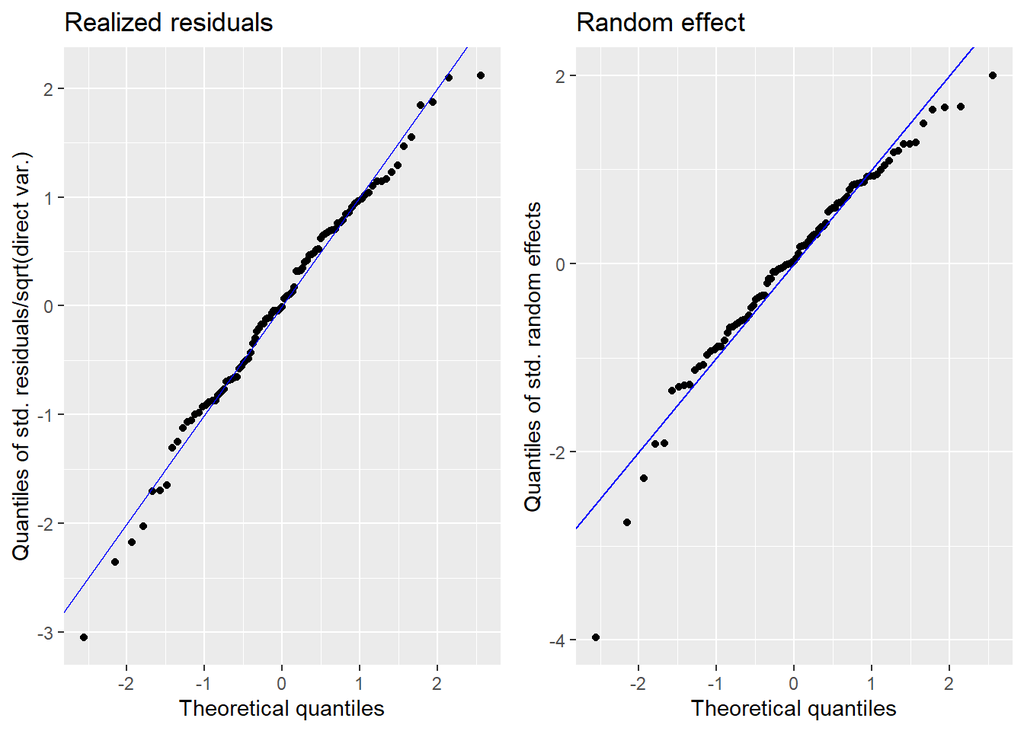

```
## Press [enter] to continue
```

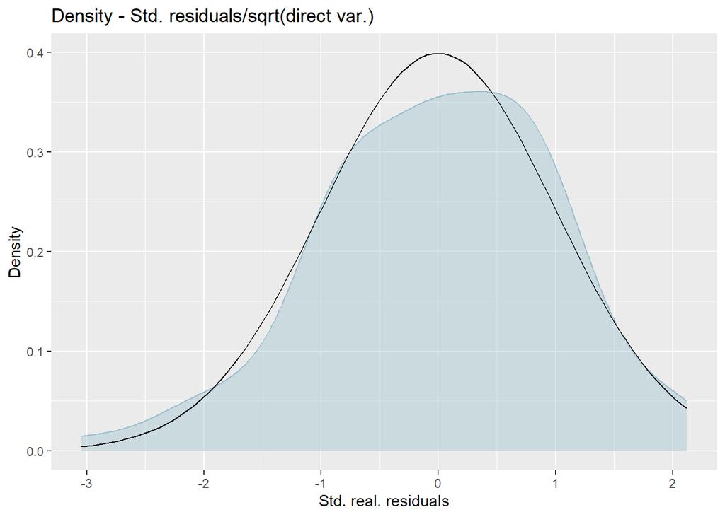

```
## Press [enter] to continue
```

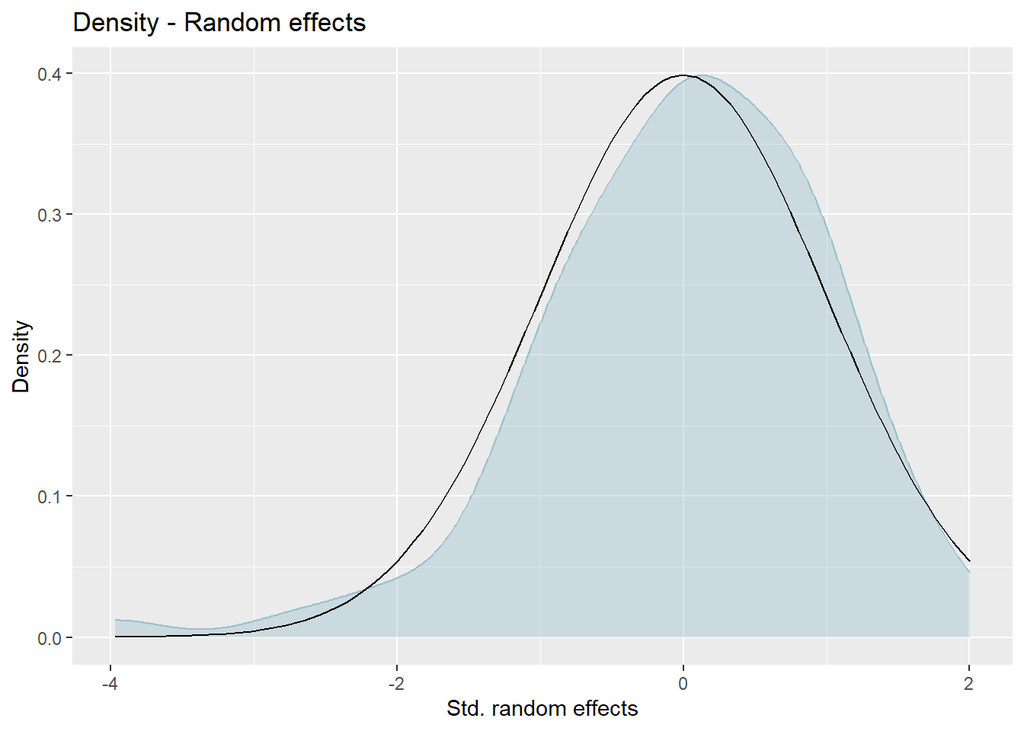

```r
# Vérification de l'ajustement du modèle retenu
plot(fh_std)
```

La comparaison des méthodes directe et de FH est présentée ci-dessous :

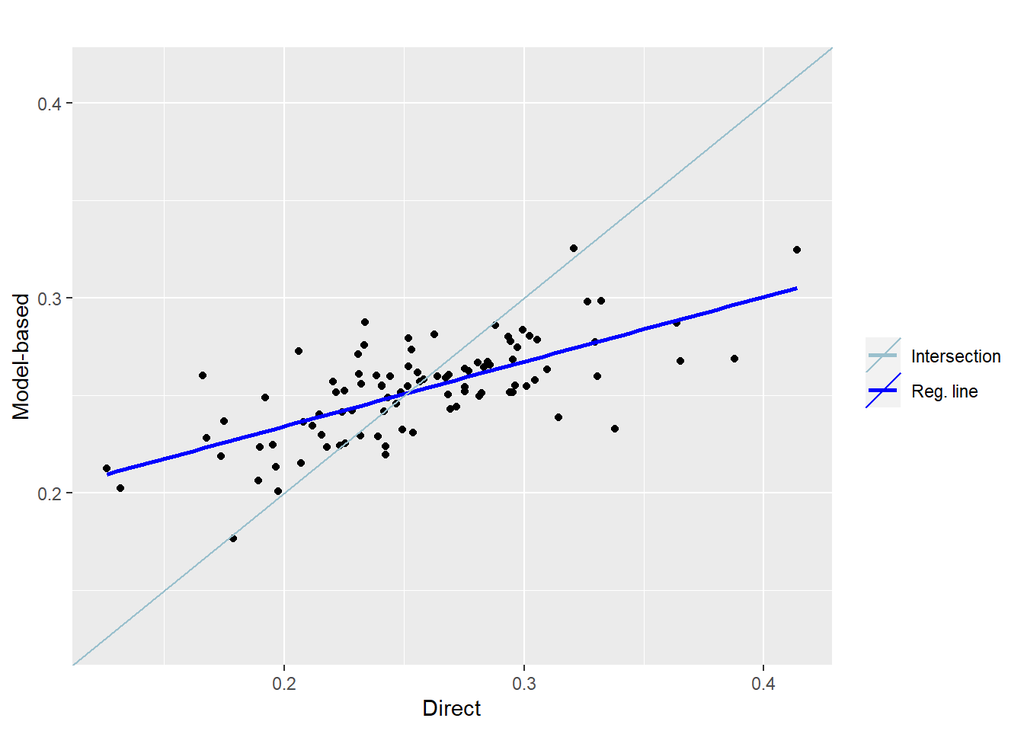

```
## Press [enter] to continue
```

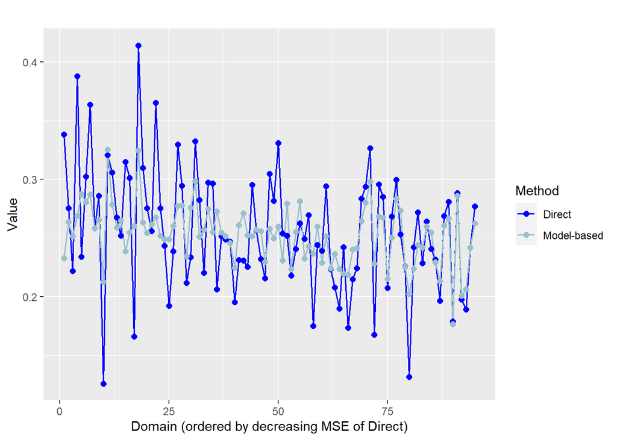

```
## Press [enter] to continue
```

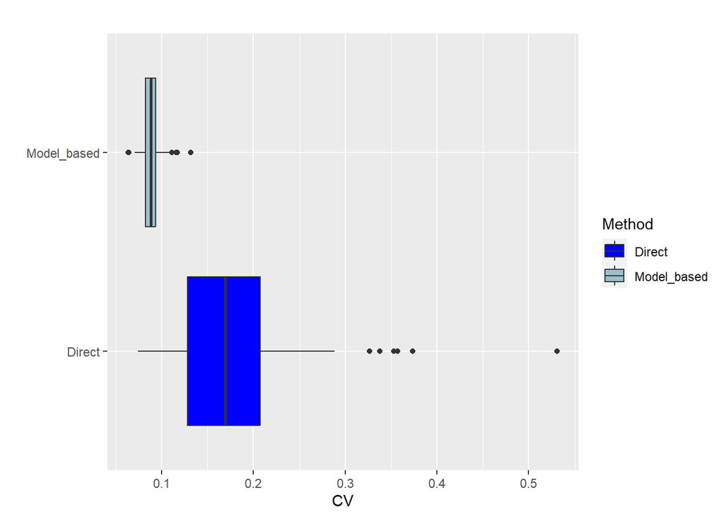

```
## Press [enter] to continue
```

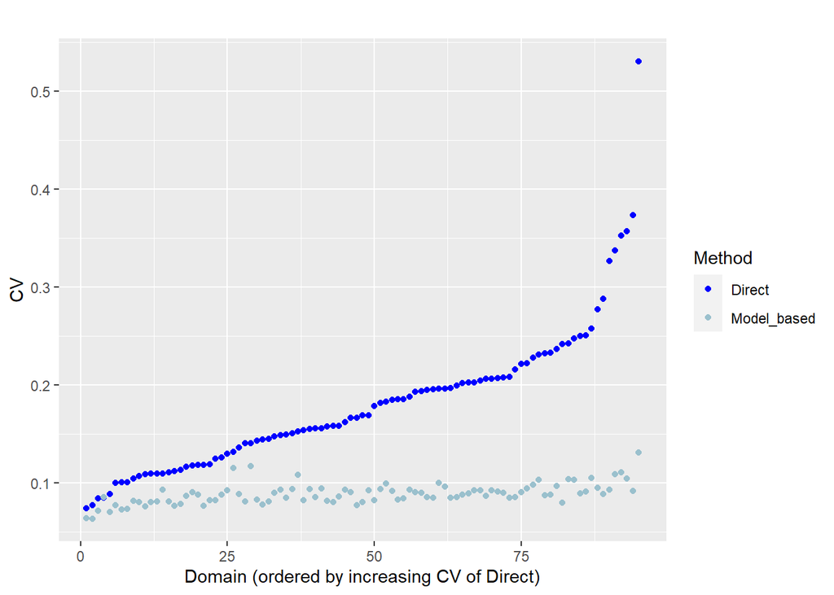

```r
# Comparaison entre méthode directe et modèle FH
compare_plot(fh_std, CV = TRUE, label = "no_title")
```

Les prévalences départementales du tabagisme quotidien et leur précision sont présentées ci-dessous (méthode directe et modèle de FH) :

```r
# Comparaison entre méthode directe et modèle FH
estimators(fh_std, MSE = TRUE,CV=TRUE)
```

```
## Indicator/s: All indicators
##    Domain    Direct   Direct_MSE  Direct_CV        FH       FH_MSE      FH_CV
## 1      01 0.1898950 0.0011885366 0.18154856 0.2234261 0.0004415594 0.09405039
## 2      02 0.2320883 0.0020549168 0.19531872 0.2556901 0.0004793957 0.08563143
## 3      03 0.3010108 0.0034935991 0.19636067 0.2544639 0.0006489724 0.10011217
## 4      04 0.3024273 0.0057676006 0.25111724 0.2803642 0.0006548617 0.09127508
## 5      05 0.1660916 0.0034348283 0.35286202 0.2599792 0.0008320519 0.11095237
## 6      06 0.2935488 0.0010845165 0.11218578 0.2801670 0.0004594288 0.07650540
## 7      07 0.2516587 0.0024237908 0.19563011 0.2547692 0.0004661105 0.08474178
## 8      08 0.3055700 0.0043452675 0.21572354 0.2784157 0.0005656791 0.08542625
## 9      09 0.2337532 0.0058250005 0.32650542 0.2873739 0.0007137401 0.09296571
## 10     10 0.1922452 0.0030748692 0.28844156 0.2486916 0.0004868105 0.08871945
## 11     11 0.2334953 0.0029660147 0.23324292 0.2755454 0.0005854380 0.08781067
## 12     12 0.2202718 0.0026266798 0.23267233 0.2568705 0.0005047507 0.08746298
## 13     13 0.2880768 0.0004943266 0.07717893 0.2856842 0.0003314714 0.06372894
```

[output cut: 82 more lines]

Ces prévalences sont également présentées dans les cartes départementales suivantes :

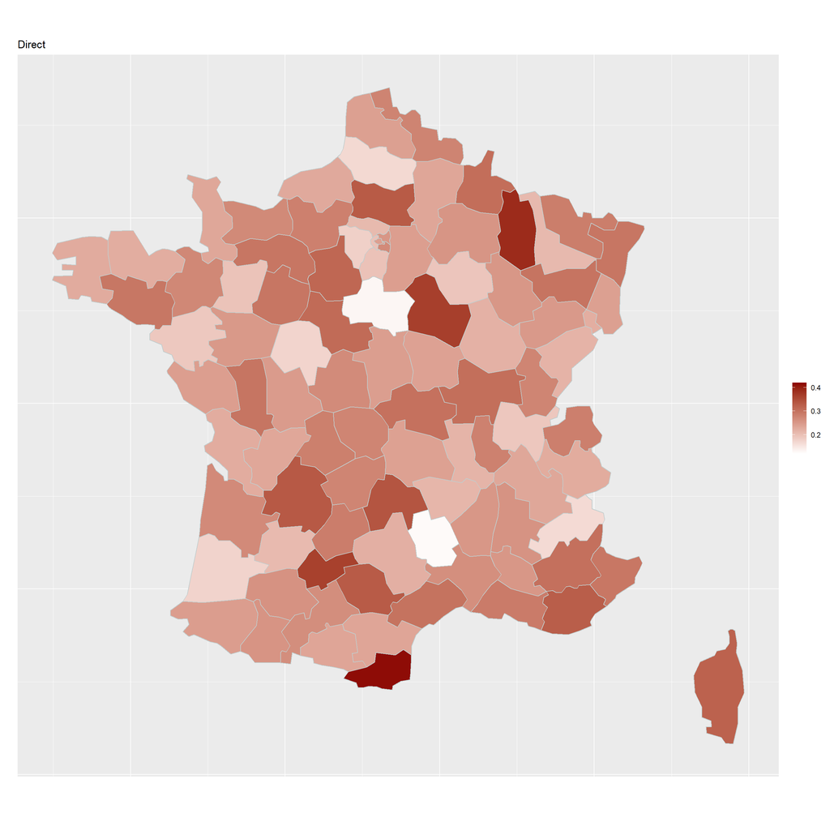

```
## Press [enter] to continue
```

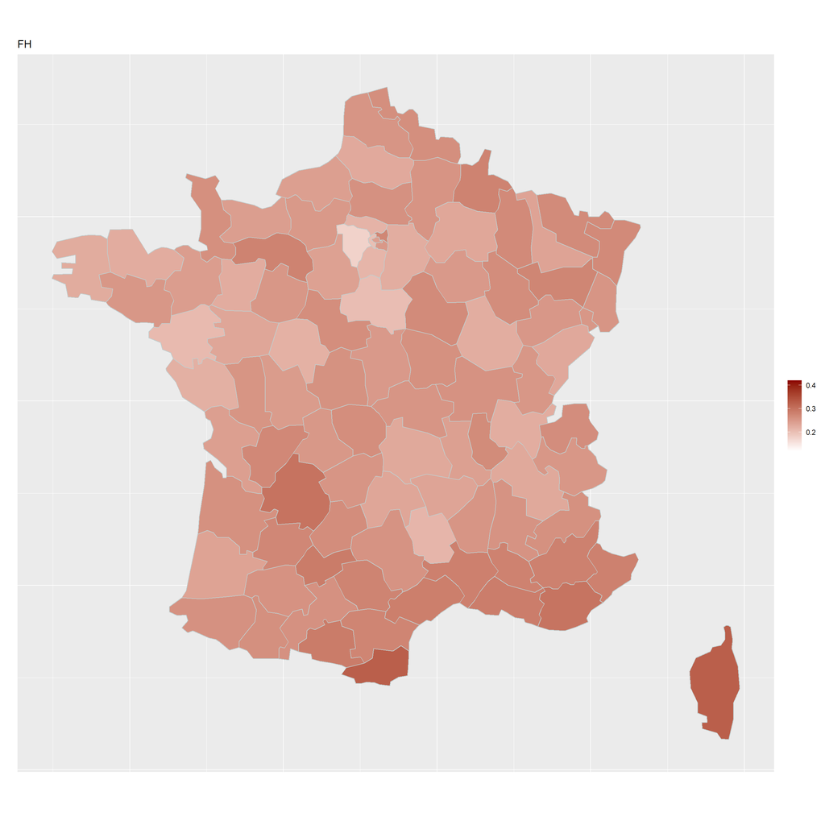

```r
depOM1=as(depOM, 'Spatial')

# Carte sans MSE
map_plot(object = fh_std, MSE = FALSE,
         map_obj = depOM1, map_dom_id = "INSEE_DEP",
         scale_points = list(Direct = list(ind = c(0.12, 0.42)
                                           ), FH = list(ind = c(0.12, 0.42) )))
```

L’estimateur obtenu avec la méthode directe respecte la propriété de l’additivité. En d’autre termes, le total des estimations directes départementales au niveau d’une région est égal à l’estimation directe de cette région et le total des estimations régionales directes est égal au total de l’estimation directe nationale. Les prévalences estimées par la méthode de FH ne respectent pas cette propriété d’où l’intérêt de mettre en cohérence les résultats nationaux/régionaux et départementaux en utilisant le benchmarking. Celui-ci est réalisé sur les estimations directes régionales qui sont précises compte tenu de l’effectif important par région de l’édition 2021 du Baromètre de Santé publique France.

Le benchmarking permet ainsi de respecter les estimations des totaux de fumeurs à chaque niveau (national, régional et départemental). Les estimations départementales de la prévalence du tabagisme quotidien obtenues par le modèle de FH avant et après benchmarking sont présentées ci-dessous :

```r
# Resultats avec benchmarking

Inseefhdirect=merge(fhbaro21data,as.data.frame(estimators(fh_std, MSE = TRUE,CV=TRUE))[,c("Domain","Direct","Direct_MSE","FH","FH_MSE")],by.x="DEPARTEMENT",by.y="Domain")

# Méthode directe par région : somme des résultats  par département (méthode directe) pour chaque région
PropSmoke.reg.dirw_region = data.frame(1*(tapply(Inseefhdirect$N_1875ANS*Inseefhdirect$Direct,Inseefhdirect$REGION,sum)/tapply(Inseefhdirect$N_1875ANS,Inseefhdirect$REGION,sum)))

# Modèle FH par région : somme des résultats  par département (méthode FH) pour chaque région
PropSmoke.reg.FH_region = data.frame(1*(tapply(Inseefhdirect$N_1875ANS*Inseefhdirect$FH,Inseefhdirect$REGION,sum)/tapply(Inseefhdirect$N_1875ANS,Inseefhdirect$REGION,sum)))

# Mettre tout dans une base
PropSmoke.reg.dirw_region$region=as.numeric(rownames(PropSmoke.reg.dirw_region))
names(PropSmoke.reg.dirw_region)=c("prevDirectRegion","REGION")
PropSmoke.reg.FH_region$region=as.numeric(rownames(PropSmoke.reg.FH_region))
names(PropSmoke.reg.FH_region)=c("prevFHRegion","REGION")

PropSmoke.FH.Dept.bench=merge(PropSmoke.reg.FH_region,PropSmoke.reg.dirw_region,by.x="REGION",by.y="REGION")

# Calcul des coefficient benchmark
PropSmoke.FH.Dept.bench$adj.FH = PropSmoke.FH.Dept.bench$prevDirect/PropSmoke.FH.Dept.bench$prevFHRegion
Inseefhdirect$REGION=as.numeric(Inseefhdirect$REGION)
PropSmoke.FH.Dept.bench.VF=merge(PropSmoke.FH.Dept.bench,Inseefhdirect,by.x="REGION",by.y="REGION")

# Calcul des prévalences départementales benchmarkées
PropSmoke.FH.Dept.bench.VF$FH.bench= PropSmoke.FH.Dept.bench.VF$FH*PropSmoke.FH.Dept.bench.VF$adj.FH
PropSmoke.FH.Dept.bench.VF[order(PropSmoke.FH.Dept.bench.VF$DEPNUM),c("nom_departement","DEPNUM","Direct","FH","FH.bench","adj.FH")]
```

```
##            nom_departement DEPNUM    Direct        FH  FH.bench    adj.FH
## 86                     Ain      1 0.1898950 0.2234261 0.2261580 1.0122273
## 31                   Aisne      2 0.2320883 0.2556901 0.2605705 1.0190873
## 83                  Allier      3 0.3010108 0.2544639 0.2575753 1.0122273
## 94 Alpes-de-Haute-Provence      4 0.3024273 0.2803642 0.2852967 1.0175930
## 91            Hautes-Alpes      5 0.1660916 0.2599792 0.2645530 1.0175930
## 89         Alpes-Maritimes      6 0.2935488 0.2801670 0.2850960 1.0175930
## 84                 Ardèche      7 0.2516587 0.2547692 0.2578843 1.0122273
## 33                Ardennes      8 0.3055700 0.2784157 0.2879438 1.0342224
## 65                  Ariège      9 0.2337532 0.2873739 0.2969717 1.0333985
## 37                    Aube     10 0.1922452 0.2486916 0.2572024 1.0342224
## 76                    Aude     11 0.2334953 0.2755454 0.2847482 1.0333985
## 72                 Aveyron     12 0.2202718 0.2568705 0.2654496 1.0333985
## 92        Bouches-du-Rhône     13 0.2880768 0.2856842 0.2907103 1.0175930
## 26                Calvados     14 0.2693230 0.2428521 0.2459468 1.0127429
```

[output cut: 81 more lines]